# Ford GoBike System Explanatory Data Analysis(EDA)

## Hany Osman

> This data set includes information about individual rides made in a bike-sharing system covering the greater San Francisco Bay area.

> > The Dataset include the following features:

> > ```
> >    - Duration of  Trip(seconds)
> >    - Start Time and Date
> >    - End Time and Date
> >    - Start Station ID
> >    - Start Station Name
> >    - Start Station Latitude
> >    - Start Station Longitude
> >    - End Station ID
> >    - End Station Name
> >    - End Station Latitude
> >    - End Station Longitude
> >    - Bike ID
> >    - User Type (Subscriber or Customer)
> >    - Member Year of Birth
> >    - Member Gender
> >    - Bike_share_for_all_trip
> > ```

> > > The raw dataset contains 183412 rows(trips,observations) and 16 columns(features). Data type in columns included 9 are numerical and 7 are object type.

```python
# import all packages and set plots to be embedded inline
import numpy as np
import pandas as pd
import matplotlib.pyplot as plt
import seaborn as sb
from datetime import datetime
%matplotlib inline
```

```python
# load the dataset csv file
df_bike=pd.read_csv('201902-fordgobike-tripdata.csv')
# get a copy for the dataframe to keep the original as it is.
df_ford= df_bike.copy()
# show the first 5 row of the dataframe
df_ford.head()
```

|  | duration_sec | start_time | end_time | start_station_id | start_station_name | start_station_latitude | start_station_longitude | end_station_id | end_station_name | end_station_latitude | end_station_longitude | bike_id | user_type | member_birth_year | member_gender | bike_share_for_all_trip |
| --- | --- | --- | --- | --- | --- | --- | --- | --- | --- | --- | --- | --- | --- | --- | --- | --- |
| 0 | 52185 | 2019-02-28 17:32:10.1450 | 2019-03-01 08:01:55.9750 | 21.0 | Montgomery St BART Station (Market St at 2nd St) | 37.789625 | -122.400811 | 13.0 | Commercial St at Montgomery St | 37.794231 | -122.402923 | 4902 | Customer | 1984.0 | Male | No |
| 1 | 42521 | 2019-02-28 18:53:21.7890 | 2019-03-01 06:42:03.0560 | 23.0 | The Embarcadero at Steuart St | 37.791464 | -122.391034 | 81.0 | Berry St at 4th St | 37.775880 | -122.393170 | 2535 | Customer | NaN | NaN | No |
| 2 | 61854 | 2019-02-28 12:13:13.2180 | 2019-03-01 05:24:08.1460 | 86.0 | Market St at Dolores St | 37.769305 | -122.426826 | 3.0 | Powell St BART Station (Market St at 4th St) | 37.786375 | -122.404904 | 5905 | Customer | 1972.0 | Male | No |
| 3 | 36490 | 2019-02-28 17:54:26.0100 | 2019-03-01 04:02:36.8420 | 375.0 | Grove St at Masonic Ave | 37.774836 | -122.446546 | 70.0 | Central Ave at Fell St | 37.773311 | -122.444293 | 6638 | Subscriber | 1989.0 | Other | No |
| 4 | 1585 | 2019-02-28 23:54:18.5490 | 2019-03-01 00:20:44.0740 | 7.0 | Frank H Ogawa Plaza | 37.804562 | -122.271738 | 222.0 | 10th Ave at E 15th St | 37.792714 | -122.248780 | 4898 | Subscriber | 1974.0 | Male | Yes |

## Data Wrangling

### 1. ASSESSMNET :

```python
# get the structure of the dataframe
df_ford.shape
```

```
(183412, 16)
```

```python
# get information of dataset
df_ford.info()
```

```
<class 'pandas.core.frame.DataFrame'>
RangeIndex: 183412 entries, 0 to 183411
Data columns (total 16 columns):
 #   Column                   Non-Null Count   Dtype
---  ------                   --------------   -----
 0   duration_sec             183412 non-null  int64
 1   start_time               183412 non-null  object
 2   end_time                 183412 non-null  object
 3   start_station_id         183215 non-null  float64
 4   start_station_name       183215 non-null  object
 5   start_station_latitude   183412 non-null  float64
 6   start_station_longitude  183412 non-null  float64
 7   end_station_id           183215 non-null  float64
 8   end_station_name         183215 non-null  object
 9   end_station_latitude     183412 non-null  float64
 10  end_station_longitude    183412 non-null  float64
 11  bike_id                  183412 non-null  int64
 12  user_type                183412 non-null  object
 13  member_birth_year        175147 non-null  float64
 14  member_gender            175147 non-null  object
 15  bike_share_for_all_trip  183412 non-null  object
dtypes: float64(7), int64(2), object(7)
memory usage: 22.4+ MB
```

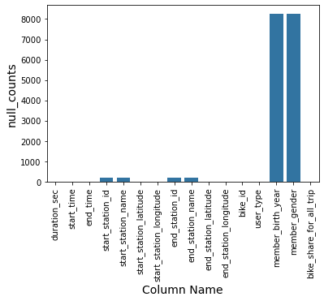

```python
# plot the null valve via bar plot
null_counts = df_ford.isna().sum()  # sum the null value
base_color = sb.color_palette()[0] # choose the color palette
sb.barplot(x= null_counts.index.values, y= null_counts, color = base_color)
plt.xticks(rotation=90); # rotation of x-axis tickes with 90  to be readable
plt.xlabel('Column Name', fontsize=14); #X axis label
plt.ylabel('null_counts',fontsize=14);# y axis label
```

#### Null values in member_ gender and member_brithy_year

#### dtypes:

> start_time as datetime or int

> end_time as datetime or int

> user_type as categorical

> member_birth_year as int.

```python
# summarize the Descriptive statistics of dataset
df_ford.describe()
```

|  | duration_sec | start_station_id | start_station_latitude | start_station_longitude | end_station_id | end_station_latitude | end_station_longitude | bike_id | member_birth_year |
| --- | --- | --- | --- | --- | --- | --- | --- | --- | --- |
| count | 183412.000000 | 183215.000000 | 183412.000000 | 183412.000000 | 183215.000000 | 183412.000000 | 183412.000000 | 183412.000000 | 175147.000000 |
| mean | 726.078435 | 138.590427 | 37.771223 | -122.352664 | 136.249123 | 37.771427 | -122.352250 | 4472.906375 | 1984.806437 |
| std | 1794.389780 | 111.778864 | 0.099581 | 0.117097 | 111.515131 | 0.099490 | 0.116673 | 1664.383394 | 10.116689 |
| min | 61.000000 | 3.000000 | 37.317298 | -122.453704 | 3.000000 | 37.317298 | -122.453704 | 11.000000 | 1878.000000 |
| 25% | 325.000000 | 47.000000 | 37.770083 | -122.412408 | 44.000000 | 37.770407 | -122.411726 | 3777.000000 | 1980.000000 |
| 50% | 514.000000 | 104.000000 | 37.780760 | -122.398285 | 100.000000 | 37.781010 | -122.398279 | 4958.000000 | 1987.000000 |
| 75% | 796.000000 | 239.000000 | 37.797280 | -122.286533 | 235.000000 | 37.797320 | -122.288045 | 5502.000000 | 1992.000000 |
| max | 85444.000000 | 398.000000 | 37.880222 | -121.874119 | 398.000000 | 37.880222 | -121.874119 | 6645.000000 | 2001.000000 |

```python
# check for duplicates
df_ford.duplicated().sum()
```

```
0
```

```python
# check the user_type for any null value
df_ford.user_type.unique()
```

```
array(['Customer', 'Subscriber'], dtype=object)
```

```python
# check the member gender for any null value
df_ford.member_gender.unique()
```

```
array(['Male', nan, 'Other', 'Female'], dtype=object)
```

## 2. Cleaning

#### Drop some columns which will not use in this study

> start_station_latitude','start_station_longitude', 'end_station_latitude', 'end_station_longitude'.

#### null values(Tidiness issues):

> member_birth_year and member_gender

#### dtypes:

> start_time as datetime or int end_time as datetime or int user_type as categorical start_station_id as str  
> end_station_id as str & bike_id as str

```python
# drop some columns which will not be used in this study

df_ford.drop(['start_station_latitude','start_station_longitude', 'end_station_latitude', 'end_station_longitude'], axis=1, inplace=True)
df_ford.head( )
```

|  | duration_sec | start_time | end_time | start_station_id | start_station_name | end_station_id | end_station_name | bike_id | user_type | member_birth_year | member_gender | bike_share_for_all_trip |
| --- | --- | --- | --- | --- | --- | --- | --- | --- | --- | --- | --- | --- |
| 0 | 52185 | 2019-02-28 17:32:10.1450 | 2019-03-01 08:01:55.9750 | 21.0 | Montgomery St BART Station (Market St at 2nd St) | 13.0 | Commercial St at Montgomery St | 4902 | Customer | 1984.0 | Male | No |
| 1 | 42521 | 2019-02-28 18:53:21.7890 | 2019-03-01 06:42:03.0560 | 23.0 | The Embarcadero at Steuart St | 81.0 | Berry St at 4th St | 2535 | Customer | NaN | NaN | No |
| 2 | 61854 | 2019-02-28 12:13:13.2180 | 2019-03-01 05:24:08.1460 | 86.0 | Market St at Dolores St | 3.0 | Powell St BART Station (Market St at 4th St) | 5905 | Customer | 1972.0 | Male | No |
| 3 | 36490 | 2019-02-28 17:54:26.0100 | 2019-03-01 04:02:36.8420 | 375.0 | Grove St at Masonic Ave | 70.0 | Central Ave at Fell St | 6638 | Subscriber | 1989.0 | Other | No |
| 4 | 1585 | 2019-02-28 23:54:18.5490 | 2019-03-01 00:20:44.0740 | 7.0 | Frank H Ogawa Plaza | 222.0 | 10th Ave at E 15th St | 4898 | Subscriber | 1974.0 | Male | Yes |

```python
# Null values in member_brithy_year
df_ford[(df_ford.member_birth_year.isnull())].shape
```

```
(8265, 12)
```

```python
# Null values in member_ gender
df_ford[(df_ford.member_gender.isnull())].shape
```

```
(8265, 12)
```

### As the two observations (Null values in both member_ gender and member_birthday_year) are the same,

### I think for every missing birth year, the gender will be missing also.

```python
##check Null values in both columns (member_brithy_year & member_ gender)
df_ford[(df_ford.member_birth_year.isnull()) & (df_ford.member_gender.isnull())].shape
```

```
(8265, 12)
```

```python
# Drop these null values and inplace= True
df_ford.dropna(inplace=True)
```

```python
# check if the data still have missing values
df_ford.isna().sum()
```

```
duration_sec               0
start_time                 0
end_time                   0
start_station_id           0
start_station_name         0
end_station_id             0
end_station_name           0
bike_id                    0
user_type                  0
member_birth_year          0
member_gender              0
bike_share_for_all_trip    0
dtype: int64
```

### I will convert start_time, end_time from object to pandas Datetime and user_type from object to category.

```python
#https://www.geeksforgeeks.org/python-pandas-series-dt-strftime/
#convert data type of start_time to datetime.
df_ford.start_time = pd.to_datetime(df_ford.start_time)
#convert data type end_time to datetime.
df_ford.end_time = pd.to_datetime(df_ford.end_time)
```

```python
#https://pandas.pydata.org/pandas-docs/stable/reference/api/pandas.Series.dt.strftime.html
# we will extract month, day of week, hour from the start_time
df_ford['start_month']= df_ford.start_time.dt.strftime('%b')
df_ford['start_day_week']= df_ford.start_time.dt.strftime('%a')
df_ford['start_hour']= df_ford.start_time.dt.strftime('%H')
df_ford.head()
```

|  | duration_sec | start_time | end_time | start_station_id | start_station_name | end_station_id | end_station_name | bike_id | user_type | member_birth_year | member_gender | bike_share_for_all_trip | start_month | start_day_week | start_hour |
| --- | --- | --- | --- | --- | --- | --- | --- | --- | --- | --- | --- | --- | --- | --- | --- |
| 0 | 52185 | 2019-02-28 17:32:10.145 | 2019-03-01 08:01:55.975 | 21.0 | Montgomery St BART Station (Market St at 2nd St) | 13.0 | Commercial St at Montgomery St | 4902 | Customer | 1984.0 | Male | No | Feb | Thu | 17 |
| 2 | 61854 | 2019-02-28 12:13:13.218 | 2019-03-01 05:24:08.146 | 86.0 | Market St at Dolores St | 3.0 | Powell St BART Station (Market St at 4th St) | 5905 | Customer | 1972.0 | Male | No | Feb | Thu | 12 |
| 3 | 36490 | 2019-02-28 17:54:26.010 | 2019-03-01 04:02:36.842 | 375.0 | Grove St at Masonic Ave | 70.0 | Central Ave at Fell St | 6638 | Subscriber | 1989.0 | Other | No | Feb | Thu | 17 |
| 4 | 1585 | 2019-02-28 23:54:18.549 | 2019-03-01 00:20:44.074 | 7.0 | Frank H Ogawa Plaza | 222.0 | 10th Ave at E 15th St | 4898 | Subscriber | 1974.0 | Male | Yes | Feb | Thu | 23 |
| 5 | 1793 | 2019-02-28 23:49:58.632 | 2019-03-01 00:19:51.760 | 93.0 | 4th St at Mission Bay Blvd S | 323.0 | Broadway at Kearny | 5200 | Subscriber | 1959.0 | Male | No | Feb | Thu | 23 |

```python
# change user_type from object to category
df_ford['user_type']= df_ford['user_type'].astype('category')
```

```python
# change start_station_id to string
df_ford.start_station_id = df_ford.start_station_id.astype(str)
```

```python
# change end_station_id to string
df_ford.end_station_id = df_ford.end_station_id.astype(str)
```

```python
#check columns data type
print(df_ford.dtypes)
```

```
duration_sec                        int64
start_time                 datetime64[ns]
end_time                   datetime64[ns]
start_station_id                   object
start_station_name                 object
end_station_id                     object
end_station_name                   object
bike_id                             int64
user_type                        category
member_birth_year                 float64
member_gender                      object
bike_share_for_all_trip            object
start_month                        object
start_day_week                     object
start_hour                         object
dtype: object
```

```python
# the structure of dataframe after cleaning step
df_ford.info()
```

```
<class 'pandas.core.frame.DataFrame'>
Int64Index: 174952 entries, 0 to 183411
Data columns (total 15 columns):
 #   Column                   Non-Null Count   Dtype
---  ------                   --------------   -----
 0   duration_sec             174952 non-null  int64
 1   start_time               174952 non-null  datetime64[ns]
 2   end_time                 174952 non-null  datetime64[ns]
 3   start_station_id         174952 non-null  object
 4   start_station_name       174952 non-null  object
 5   end_station_id           174952 non-null  object
 6   end_station_name         174952 non-null  object
 7   bike_id                  174952 non-null  int64
 8   user_type                174952 non-null  category
 9   member_birth_year        174952 non-null  float64
 10  member_gender            174952 non-null  object
 11  bike_share_for_all_trip  174952 non-null  object
 12  start_month              174952 non-null  object
 13  start_day_week           174952 non-null  object
 14  start_hour               174952 non-null  object
dtypes: category(1), datetime64[ns](2), float64(1), int64(2), object(9)
memory usage: 20.2+ MB
```

### Create a new column for age (Age = today's date - member_birth_year)

```python
# define the age column by using datetime.now library.
df_ford['age'] = datetime.now().year - df_ford.member_birth_year # today's date and time.
# show the statistic of age column.
df_ford.age.describe()
```

```
count    174952.000000
mean         36.196865
std          10.118731
min          20.000000
25%          29.000000
50%          34.000000
75%          41.000000
max         143.000000
Name: age, dtype: float64
```

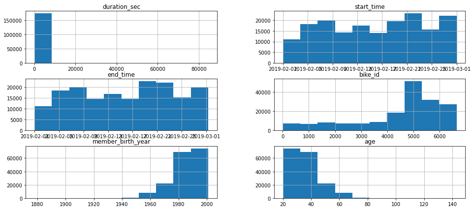

```python
#view The numerical features of interest
df_ford.hist(figsize=(16,7));
```

### What is/are the main feature(s) of interest in your dataset?

> The main features of interst are trip duration, user_type,bake_id and member_gender. In addition to age and start station.

### What features in the dataset do you think will help support your investigation into your feature(s) of interest?

> I think the following columns will support my investigstion:

> duration_sec, user_type, age, member_gender, start_time,bike id, start_station_id and start_station_name.

## Univariate Exploration

> In this section, I will investigate distributions of individual variables. If there is unusual points or outliers, i will take a deeper look to clean things up and take a look at relationships between variables.

### The Distribution of Trips Duration (sec)

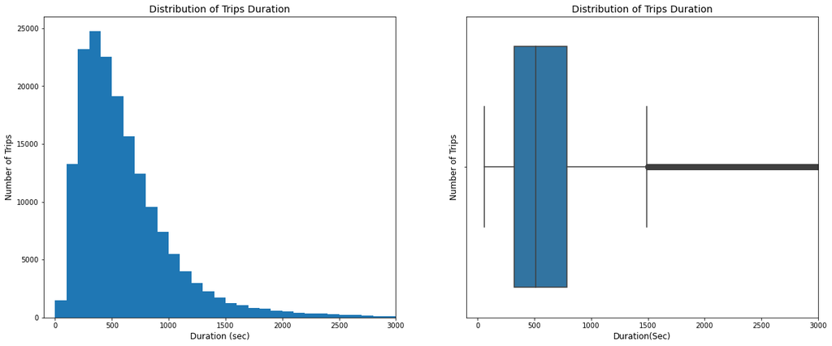

```python
# plotting types of users.
plt.figure(figsize=[20,8])
# left side
plt.subplot(1,2,1)
# set bins for the histogram
bins= np.arange(0, df_ford['duration_sec'].max()+5,100)
# plot histogram (counts and duration_sec ) by using matplotlib.pyplot library
plt.hist(data=df_ford, x='duration_sec', bins=bins)
plt.ylabel('Number of Trips', fontsize=12) # label for y axis(count of bike rides)
# label for x axis(Duration of bike trips (100 sec bins))
plt.xlabel('Duration (sec)', fontsize=12);
plt.xlim((-100,3000))
# Title for histogram(Distribution of bike trip duration)
plt.title('Distribution of Trips Duration', fontsize=14)
# Right side; box chart
# Outliers may be consider greater than 90 years and above.
plt.subplot(1,2,2)
# select color palette
base_color=sb.color_palette()[0]
#select box chart from seaborn to illustrate the outlier.
sb.boxplot(data=df_ford, x='duration_sec', color =base_color);
plt.xlim((-100,3000))
# set title for box chart
plt.title('Distribution of Trips Duration', fontsize=14)
#label for x axis
plt.xlabel('Duration(Sec)',fontsize=12);
#label for y axis
plt.ylabel('Number of Trips', fontsize=12);
```

#### From the above histogram the data is right shewed in the distribution and the bulk of the trip take less than 2000 seconds (33 minutes). In addition to the presence of oultiers which are greater than whisker length as seen above

#### So, I prefer log transformation.

```python
# describe log of bins to define their value
bin_max=np.log10(df_ford.duration_sec.describe())
```

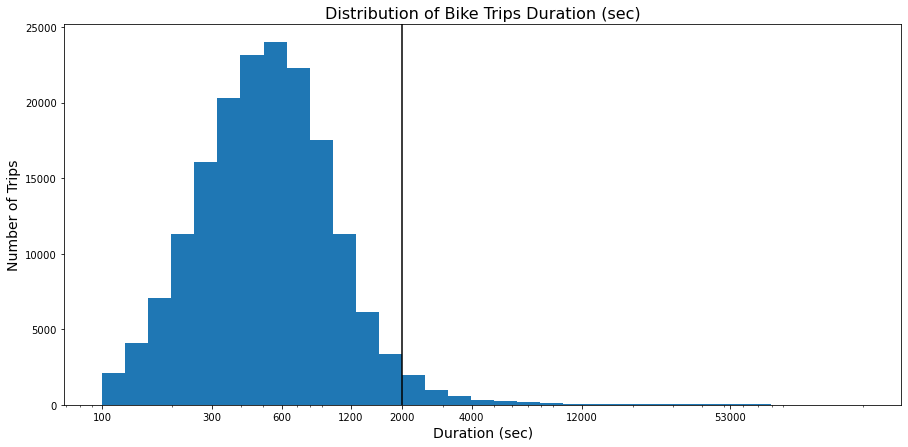

```python
# format the bins
bins = 10 ** np.arange(2, bin_max.max() + 0.1, 0.1)
# define the figure size
plt.figure(figsize=[15,7])
# plot histogram with defined ticks and labels.
plt.hist(data = df_ford, x = 'duration_sec', bins =bins)
ticks = [100, 300, 600 , 1200, 2000,4000, 12000,53000]#Ticks are markers denoting data points on x-axes.
labels = ['{}'.format(v) for v in ticks] #labels corresponding to tick marks
plt.xscale('log')# log -format of x axis.
plt.xticks(ticks, labels)
plt.xlabel('Duration (sec)',fontsize=14)# x-axis label
plt.ylabel('Number of Trips', fontsize=14)# y-axis label
plt.axvline(x=2000, color = "black")
plt.title('Distribution of Bike Trips Duration (sec)',fontsize=16);# title of chart
```

After log tranformed, the histogram of trip duration show that most of the values are less than 2000 sec(33 min) with peak around 600 sec(10 min).

### Looking at the distribution of age.

```python
# log tranformation for plotting a histogram chart.
age_log=np.log10(df_ford.age.describe())
age_log
```

```
count    5.242919
mean     1.558671
std      1.005126
min      1.301030
25%      1.462398
50%      1.531479
75%      1.612784
max      2.155336
Name: age, dtype: float64
```

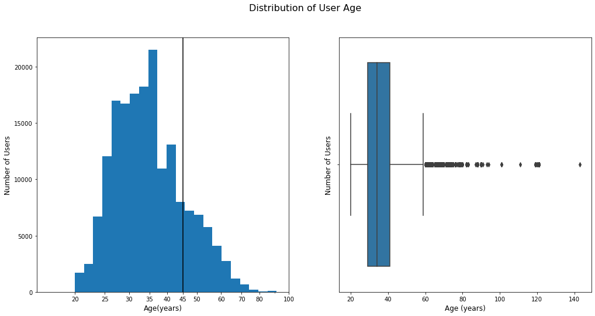

```python
# plotting types of users by two different charts to search for any insights.
plt.figure(figsize=[17,8])
plt.suptitle('Distribution of User Age',fontsize=16)#set title for  both charts
# Left side
# the position of first chart
plt.subplot(1,2,1)#(subplot () function adds subplot subplot to a current figure at the specified grid position.)
bins = 10 ** np.arange(1, 2.5 + 0.03 ,0.03)
plt.hist(data=df_ford, x='age', bins=bins)
ticks = [20,25, 30, 35 ,40, 45,50, 60, 70, 80, 100] #Ticks are markers denoting data points on x-axes.
labels = ['{}'.format(v) for v in ticks]#labels corresponding to tick marks
plt.xscale('log')
plt.xticks(ticks, labels)
plt.axvline(x=45, color = "black")
plt.xlabel('Age(years)',fontsize=12) # y axis label
plt.ylabel('Number of Users',fontsize=12)# x axis label
plt.xlim(15,100) # set the x limits of x-axis
# Right side box chart
# check for the Outliers.
# the position of second chart
plt.subplot(1,2,2)
# define the color palette for seaborn
base_color=sb.color_palette()[0]
sb.boxplot(data=df_ford, x='age', color =base_color);
plt.xlabel('Age (years)',fontsize=12); # X axis label
plt.ylabel('Number of Users', fontsize=12);# y axis label
```

### Deep investigation for the outliers in the age column.

```python
# create dataframe df-90
df_90 = df_ford[['duration_sec','member_birth_year', 'member_gender', 'age',  'user_type', 'start_day_week','start_hour','start_station_name','end_station_name','bike_id']]
```

```python
# look for the outlier in the age column
np.sort(df_90.age.unique())
```

```
array([ 20.,  21.,  22.,  23.,  24.,  25.,  26.,  27.,  28.,  29.,  30.,
        31.,  32.,  33.,  34.,  35.,  36.,  37.,  38.,  39.,  40.,  41.,
        42.,  43.,  44.,  45.,  46.,  47.,  48.,  49.,  50.,  51.,  52.,
        53.,  54.,  55.,  56.,  57.,  58.,  59.,  60.,  61.,  62.,  63.,
        64.,  65.,  66.,  67.,  68.,  69.,  70.,  71.,  72.,  73.,  74.,
        75.,  76.,  77.,  78.,  79.,  80.,  82.,  83.,  87.,  88.,  90.,
        91.,  93.,  94., 101., 111., 119., 120., 121., 143.])
```

```python
#consider the age greater than 90 years is outliers
df_90 = df_90 [df_90["age"] > 90]
```

```python
# Get the outlier count greater than 90 years.
df_90.member_birth_year.value_counts()
```

```
1900.0    53
1902.0    11
1901.0     6
1920.0     3
1930.0     1
1910.0     1
1928.0     1
1927.0     1
1878.0     1
Name: member_birth_year, dtype: int64
```

```python
# The distribution of age regard user_type.
df_90.user_type.value_counts()
```

```
Subscriber    71
Customer       7
Name: user_type, dtype: int64
```

```python
# most of them are subscriber.
df_90.member_gender.value_counts()
```

```
Male      61
Female    14
Other      3
Name: member_gender, dtype: int64
```

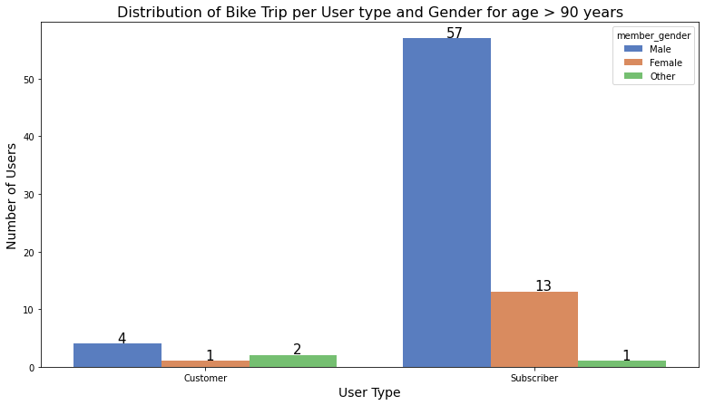

```python
# determine member_gender  for every user_type when age >90
ax = plt.subplots(figsize = (13,7))
#plot countplot chart from seaborn library with order regard to member_gender
ax=sb.countplot(data=df_90, x='user_type', hue='member_gender',palette= 'muted');
ax.set_xlabel('User Type',fontsize=14)# set label for x-axis
ax.set_ylabel('Number of Users',fontsize=14)# set label for y-axis
ax.set_title('Distribution of Bike Trip per User type and Gender for age > 90 years', fontsize=16);#set title for chart
# show count and  annotate for each bar.
for p in ax.patches:
    ax.text (p.get_x() + p.get_width() / 2,p.get_height()+ 0.25,p.get_height(), fontsize = 15);
```

I consider the age greater than 90 years is outliers, so there are 78 bike rider above 90 years old,71 are subscriber users (57 male,13 female and 1 from other gender) and 7 are Customer users(4 male, 1 female and 2 other gender)

### Take a look at the distribution of User_ Type

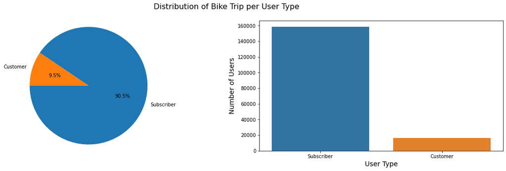

```python
# plotting types of users.
plt.figure(figsize=[20,5])
plt.suptitle('Distribution of Bike Trip per User Type', fontsize=16)#set title for  both charts
# left side
# distribution via pie chart
plt.subplot(1,2,1)
type_counts= df_ford['user_type'].value_counts()
plt.pie(type_counts, labels = type_counts.index,autopct='%1.1f%%', startangle =180)# distribution via pie chart
plt.axis('square'); #where the ranges for both axes occupy are equal to the length in plot.
# Right side
plt.subplot(1,2,2)
# distribution via bar chart
type_count=df_ford.user_type.value_counts().keys()
sb.countplot(data= df_ford, x='user_type',order=type_count)#Show the counts of observations in each categorical bin using bars.
plt.xlabel('User Type',fontsize=14)# set label for x-axis
plt.ylabel('Number of Users',fontsize=14);# set label for y-axis
```

Subscriber users(90.5%) are heigher than Customer users(9.5%).

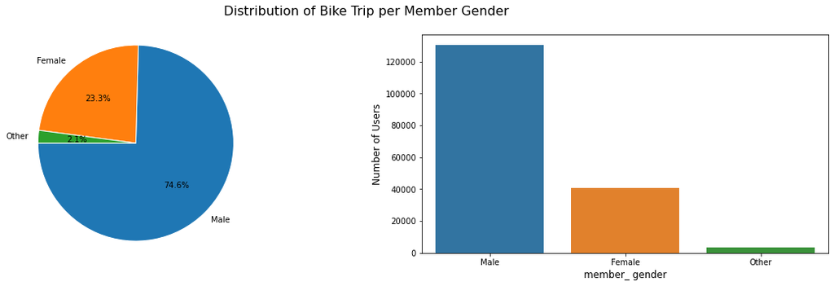

```python
# plotting the Distribution of Bike Trip per User Gender
plt.figure(figsize=[20,5])
plt.suptitle('Distribution of Bike Trip per Member Gender', fontsize=16)#set title for  both charts
# left side
# plotting genders of user via pie chart
plt.subplot(1,2,1)
gender_sorted= df_ford['member_gender'].value_counts()
# Create a pieplot with specific wedgeprops option
plt.pie(gender_sorted, labels = gender_sorted.index,autopct='%1.1f%%', startangle =180, wedgeprops = { 'linewidth' : 1, 'edgecolor' : 'white' })# distribution via pie chart
plt.axis('square');
# plotting genders of user on bar chart.
# Right side
plt.subplot(1,2,2)
member_count=df_ford.member_gender.value_counts().keys()
#plot countplot chart from seaborn library with order regard to member_count
sb.countplot(data= df_ford, x='member_gender',order=member_count)
plt.xlabel('member_ gender', fontsize=12)# set label for x-axis
plt.ylabel('Number of Users', fontsize=12)#  set label for y-axis
plt.show()
```

It appears from the figures that the male gender is a higher position than females and others.

```python
#check start month counts
df_ford['start_month'].value_counts()
```

```
Feb    174952
Name: start_month, dtype: int64
```

```python
#check  start days of the week counts
df_ford['start_day_week'].value_counts()
```

```
Thu    33712
Tue    30584
Wed    28426
Fri    27663
Mon    25641
Sun    14512
Sat    14414
Name: start_day_week, dtype: int64
```

```python
#check  start hour of day count
df_ford['start_hour'].value_counts()
```

```
17    20904
08    20227
18    16118
09    15204
16    13473
07    10231
19     9424
15     8646
12     8220
13     8098
10     7970
14     7677
11     7461
20     6211
21     4400
06     3293
22     2793
23     1572
00      893
05      866
01      525
02      355
04      227
03      164
Name: start_hour, dtype: int64
```

### Distribution of Bike Trip per Months, start_day of the week and start_hour of the day.

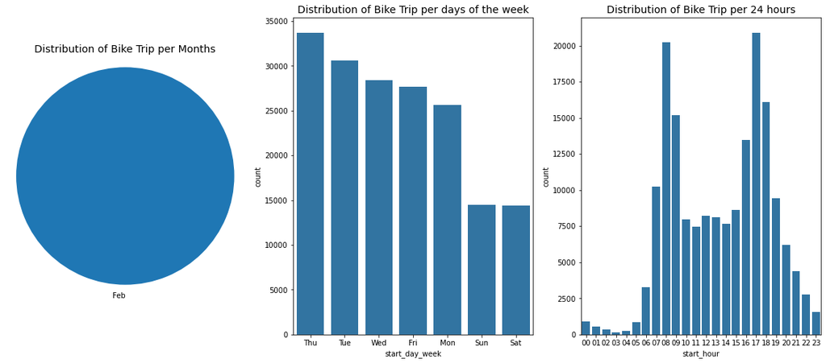

```python
# set the sizefor the three figures.
plt.figure(figsize=[20,8])
base_color = sb.color_palette()[0] # set the base color palette for both charts
# Left side chart
#Distribution of Bike Trip per start_month chart
plt.subplot(1,3,1)#define the number of rows and columns of the subplot grid for pie chart
start_month= df_ford['start_month'].value_counts()
# Create a pieplot for start_month
plt.pie(start_month, labels = start_month.index, startangle = 90)# distribution via pie chart
plt.axis('square');
plt.title('Distribution of Bike Trip per Months', fontsize=14);# set title for chart
# Middle chart
#Distribution of Bike Trip per start_days of the week
plt.subplot(1,3,2)#define the number of rows and columns of the subplot grid for coutplot chart
#plot countplot chart from seaborn library with order regard to start_day_week.
sb.countplot(data = df_ford, x = 'start_day_week', color = base_color, order=df_ford.start_day_week.value_counts().index)
plt.title('Distribution of Bike Trip per days of the week', fontsize=14);# set title for chart
# Right side chart
plt.subplot(1,3,3)#define the number of rows and columns of the subplot grid for bar chart.
#Distribution of Bike Trip per start_hour of the day.
hour_count=df_ford.groupby('start_hour').size()
hour_count = hour_count.reset_index(name = 'count')
sb.barplot(data = hour_count, x = 'start_hour',y='count', color = base_color);# Plot barplot chart from seaborn library.
plt.title('Distribution of Bike Trip per 24 hours', fontsize=14);# set title for chart
```

We can summerized charts above as follows:-

> 1- I think all data has been collected in February month.So, month variable is not helping our study.

> 2- Thursday, Wednesday and Tuesday had a close distribution and have the most bike riders,

> 4- The bike riding have a peak at 7-9 am and from 16: 18 (4-6 pm).

> 5-17 (5 PM) and 8 (8 AM) o'clock is the most hours have(traffic) bike riders.

### Take a look at start station name and end station name.

```python
#The high frequent  10 start station for bike rider
start_stat=df_ford['start_station_name'].value_counts(sort=True, ascending=False)[:10]
```

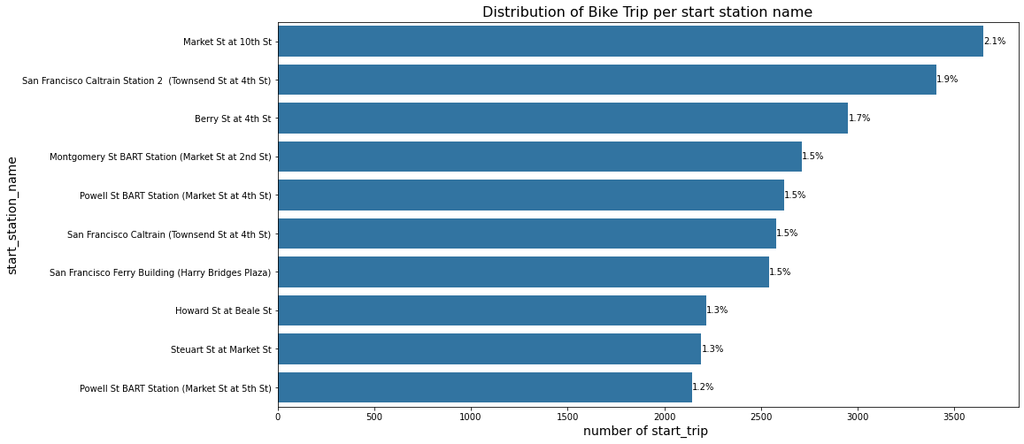

```python
# plot  a bar chat for the distribution of Bike Trip per start station name
plt.figure(figsize=[15,8])
base_color = sb.color_palette()[0] #use seaborn color palette
#plot countplot chart from seaborn library with order regard to start station name.
sb.countplot(data = df_ford, y = 'start_station_name', color = base_color, order=df_ford.start_station_name.value_counts().index[:10])
plt.title('Distribution of Bike Trip per start station name', fontsize=16);#set title for chart
plt.xlabel('number of start_trip ',fontsize=14);#set x-axis label
plt.ylabel('start_station_name',fontsize=14);#set y-axis label
# labelling percentage for every  start station
start_label = df_ford.start_station_name.value_counts().head(10)
for v in range(start_label.shape[0]):
  label= start_label[v]
  pct_string = '{:0.1f}%'.format(100*label/df_ford.shape[0])# show count and  annotate for each bar.
  plt.text(label+1, v, pct_string, va = 'center');
```

The most frequent start station are :

> 1-Market St at 10th St,

> 2-San Francisco Caltrain Station 2 (Townsend St at 4th St),

> 3-Berry St at 4th St

> 4-Montgomery St BART Station (Market St at 2nd St),

> 5-Powell St BART Station (Market St at 4th St),

> 6-San Francisco Caltrain (Townsend St at 4th St)

> 7-San Francisco Ferry Building (Harry Bridges Plaza)

> 8-Howard St at Beale St

> 9-Steuart St at Market St

> 10-Powell St BART Station (Market St at 5th St)

```python
#The high frequent 10 end station for bike rider
end_stat=df_ford['end_station_name'].value_counts(sort=True, ascending=False)[:10]
```

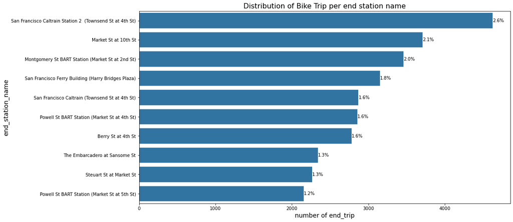

```python
plt.figure(figsize=[15,8])
#plot countplot chart from seaborn library with order regard to end station name.
sb.countplot(data = df_ford, y = 'end_station_name', color = base_color, order=df_ford.end_station_name.value_counts().index[:10]);
plt.title('Distribution of Bike Trip per end station name', fontsize=16);#set title for chart
plt.xlabel('number of end_trip',fontsize=14);#set x-axis label
plt.ylabel('end_station_name',fontsize=14);#set y-axis label
# show percentage for every station
end_label = df_ford.end_station_name.value_counts().head(10)
for v in range(end_label.shape[0]):
  label= end_label[v]
  pct_string = '{:0.1f}%'.format(100*label/df_ford.shape[0])# show annotate for each bar.
  plt.text(label+1, v, pct_string, va = 'center');
```

The most frequent end station are :

> 1-San Francisco Caltrain Station 2 (Townsend St at 4th St)

> 2-Market St at 10th St

> 3-Montgomery St BART Station (Market St at 2nd St)

> 4-San Francisco Ferry Building (Harry Bridges Plaza)

> 5-San Francisco Caltrain (Townsend St at 4th St)

> 6-Powell St BART Station (Market St at 4th St)

> 7-Berry St at 4th St

> 8-The Embarcadero at Sansome St

> 9-Steuart St at Market St

> 10-Powell St BART Station (Market St at 5th St)

#### As most of start station is the same as the end station, this confirms that most bike rider use bike to go to work or school mainly not in a picnic.

## Take a look at the distribution of Bike_id

```python
#check  the number of trip per every bike_id
df_ford.bike_id.value_counts()
```

```
4794    179
4814    172
5175    167
4450    166
5145    165
       ...
3222      1
992       1
3114      1
6601      1
302       1
Name: bike_id, Length: 4607, dtype: int64
```

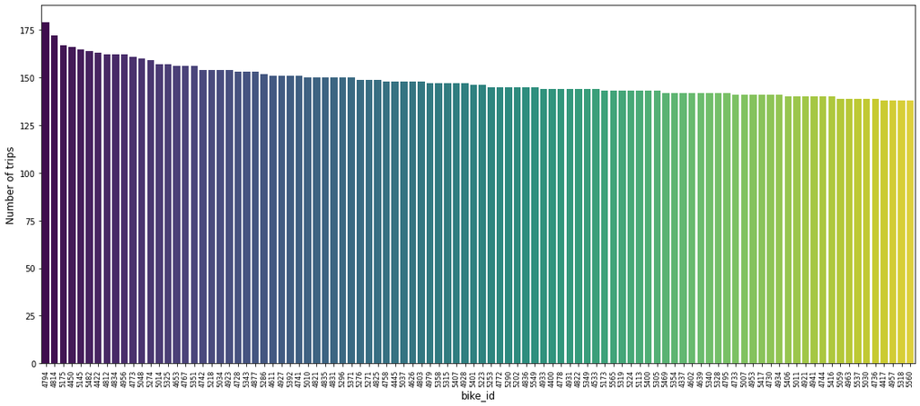

```python
# plot the distrubution of the number of trip per every bike_id
plt.figure(figsize=[19,8])
bike_count=df_ford.bike_id.value_counts().keys()
#plot countplot chart from seaborn library with order regard to bike_count
sb.countplot(data= df_ford, x='bike_id',order=bike_count[:100], palette= 'viridis')
plt.xlabel('bike_id', fontsize=12)# set label for x-axis
plt.ylabel('Number of trips', fontsize=12)#  set label for y-axis
plt.xticks(rotation=90, fontsize=8); # rotation of x-axis tickes with 90  to be readable
plt.show()
```

#### This chart can help in scheduled maintenance for the bike, as the frequent use of bikes ranged from 1 trip (min) to 179 trips/bike (max)

### Distribution of bike_share_for_all_trip

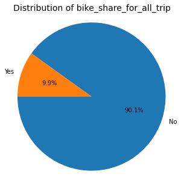

```python
# distribution via pie chart per bike_share_for_all_trip
plt.figure(figsize=[12,5])
type_counts= df_ford['bike_share_for_all_trip'].value_counts()
plt.pie(type_counts, labels = type_counts.index,autopct='%1.1f%%', startangle =180)# distribution via pie chart
plt.axis('square'); #where the ranges for both axes occupy are equal to the length in plot.
plt.title('Distribution of bike_share_for_all_trip',fontsize=14);
```

#### Most users (90.1%) didn't use the bike _share for all trips.

### Discuss the distribution(s) of your variable(s) of interest. Were there any unusual points? Did you need to perform any transformations?

### Discuss the distribution(s) of your variable(s) of interest. Were there any unusual points? Did you need to perform any transformations?

> Duration_sce was right skweed in the distribution and had many outliers; a scale transformation (log) was required. Due to the presence of oulters which are greater than whisker length in box chart which are above the higher whisker that are more than 1.5 times the IQR above the third quartile.The bulk of the trip take less than 2000 seconds (33 minutes).

> Age has some problems with outliers, and Log scale was needed.The distribution is more concentrated between 20 and 45 years old

> I consider the age greater than 90 years is outliers, so there are 78 bike rider above 90 years old,71 is subscriber users (57 male,13 female and 1 from other gender) and 7 are Customer users(4 male, 1 female, and 2 other gender).

> Subscriber (90.5%) users are heigher than Customer (9.5%) users

> Male gender (74.6%)is heigher portion than female(23.3%) and others (2.1%) gender.

> All data has been collected in February month so, month have no attribute with us.

> Thursday, Wednesday and Tuesday had a close distribution and have the most bike riders than Saturday and Sunday.

> The bike riding have a peak at 7-9 am and from 16:18 (4-6 pm). but 17 o'clock (5 PM) and 8 (AM) o'clock are the most hours have bike riders( traffic) per 24 hours.

> As most of start station is the same as the end station, this confirm that most bike rider use bike to go to work or school mainly not in a picnic.

> The frequent riding bikes ranged from 1 trip/bike to 179 trips/bike (max), This may help in scheduled maintenance for the bikes and readyability.

### Of the features you investigated, were there any unusual distributions? Did you perform any operations on the data to tidy, adjust, or change the form of the data? If so, why did you do this?

> Duration_sec was right skewed in the distribution and has many outliers; a scale transformation (log) was required.

> The distribution of age is Skewed to the right and Log scale was needed, in addition to outliers problems.

## Bivariate Exploration

> In this section, i will investigate relationships between pairs of variables in my data.

Some intersting relationship.

> Duration of Bike Trips(sec) and Age,

> Duration_trip and member Gender,

> Duration_trip and User_type,

> star hour of the day and user type,

> star hour of the day and member gender,

> star hour of the day and Days of the week,

> User Type and Member Gender,

> Member Gender and Days,

> Distribution of Bike Trip per start and end station name in term of User type &

> Distribution of Bike Trip per start and end station name in terms of start_day_week

### The relation between Duration of Bike Trips(sec) and Age

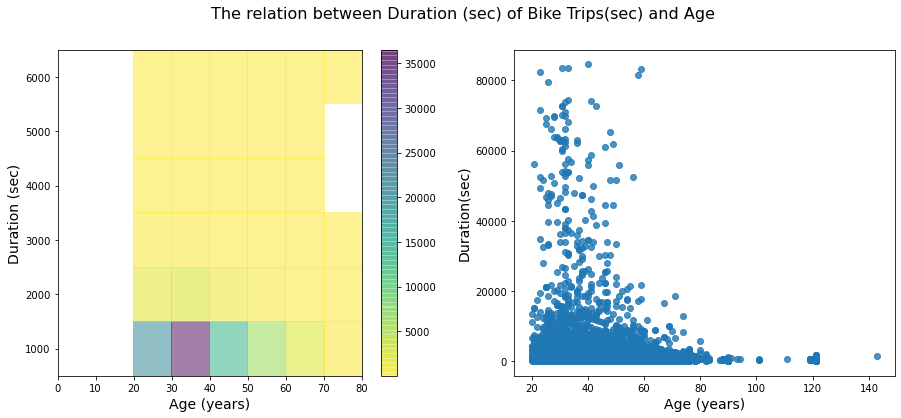

```python
# define figure size
plt.figure(figsize=[15,6])
plt.suptitle('The relation between Duration (sec) of Bike Trips(sec) and Age',fontsize=16)
# left side
#Heat map(2D histogram)
plt.subplot(1, 2, 1)
bins_x = np.arange(0, 90, 10)# set bins for x-axis
bins_y = np.arange(500, 7000, 1000)# set bins for y-axis
plt.hist2d( data= df_ford, x='age', y='duration_sec',# use heat map chart,set cmin=0.5 to elminate bins with no counts
           bins = [bins_x, bins_y],alpha = 0.5,cmin=0.5, cmap='viridis_r')#use viridis_r palette from matplotlib.pyplot.
plt.xlabel('Age (years)',fontsize=14)#set x-axis label
plt.ylabel('Duration (sec)',fontsize=14)#set y-axis label
plt.colorbar();
# Right side chart
plt.subplot(1, 2,2)
age_sec=sb.regplot( data= df_ford, x='age', y='duration_sec',fit_reg=False)# fit_reg= false to remove regression line
age_sec.set_xlabel('Age (years)',fontsize=14)#set x-axis label
age_sec.set_ylabel('Duration(sec)',fontsize=14);#set y-axis label
```

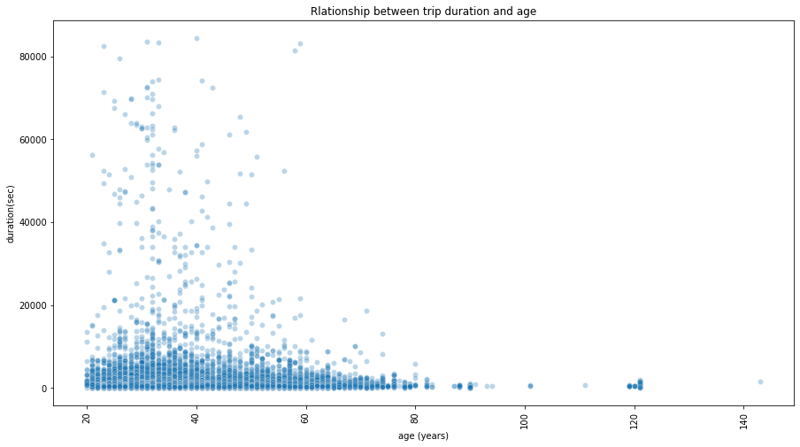

```python
plt.figure(figsize = (15,8))
sb.scatterplot(data = df_ford, x = "age", y = "duration_sec", alpha = 0.3)
plt.title("Rlationship between trip duration and age")
plt.xlabel('age (years)')
plt.ylabel('duration(sec)')
plt.xticks(rotation = 90)
#lt.legend(bbox_to_anchor=(1.05, 1), loc='upper left')

plt.show()
```

#### The most frequent bike riders have ages between 20 and 45( youth_members)

#### Youth_members (between 20 and 45) achieved higher trips duration.

#### From scatter plot it is appeared that a negative relationship between duration and age. The shorter the duration of the trip, the older the user

### The relation between Duration of Bike Trips (sec) and member gender.

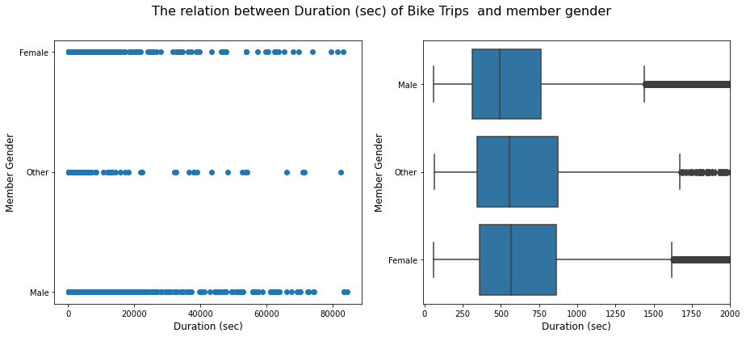

```python
plt.figure(figsize=[15,6])
plt.suptitle('The relation between Duration (sec) of Bike Trips  and member gender',fontsize=16)
# left side
plt.subplot(1, 2, 1)
plt.scatter(data=df_ford,y="member_gender", x="duration_sec")
plt.xlabel('Duration (sec)',fontsize=12)#set x-axis label
plt.ylabel('Member Gender',fontsize=12);#set y-axis label
# Right side
plt.subplot(1, 2, 2)
sb.boxplot(data =df_ford, y = 'member_gender', x = 'duration_sec', color = base_color)
plt.xlim([-10, 2000])# limit the duration to 2000 sec to get a clear view.
plt.xlabel('Duration (sec)',fontsize=12)#set x-axis label
plt.ylabel('Member Gender',fontsize=12);#set y-axis label
```

#### Male bike riders are a higher number than other and female riders. On contract, Other and females ride bikes on longer trips than male riders.

### The relation between Duration of Bike Trips (sec) and User type.

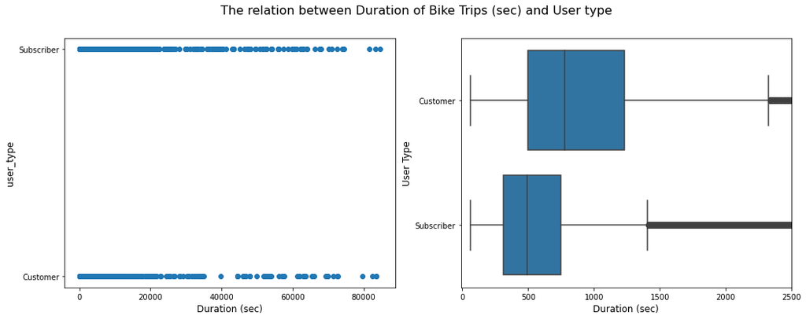

```python
# plot the relation between duration of Bike Trips and User-type
plt.figure(figsize=[17,6])
plt.suptitle('The relation between Duration of Bike Trips (sec) and User type', fontsize=16)
base_color = sb.color_palette()[0]
# left side
plt.subplot(1, 2, 1)
plt.scatter(data=df_ford,y="user_type", x="duration_sec")
plt.xlabel('Duration (sec)',fontsize=12)#set y-axis label
plt.ylabel('user_type',fontsize=12);#set x-axis label
# Right side
plt.subplot(1, 2, 2)
sb.boxplot(data = df_ford, y = 'user_type', x = 'duration_sec', color = base_color)
plt.xlim([-10, 2500]) # set limits for x_axis to 2500 to exclude outlier.
plt.ylabel('User Type',fontsize=12)#set y-axis label
plt.xlabel('Duration (sec)',fontsize=12)#set x-axis label
plt.show();
```

#### Subscriber users are greater than customers in number of trips but, customer users have a longer trip duration than Subscriber.

### The relation between User type and member gender.

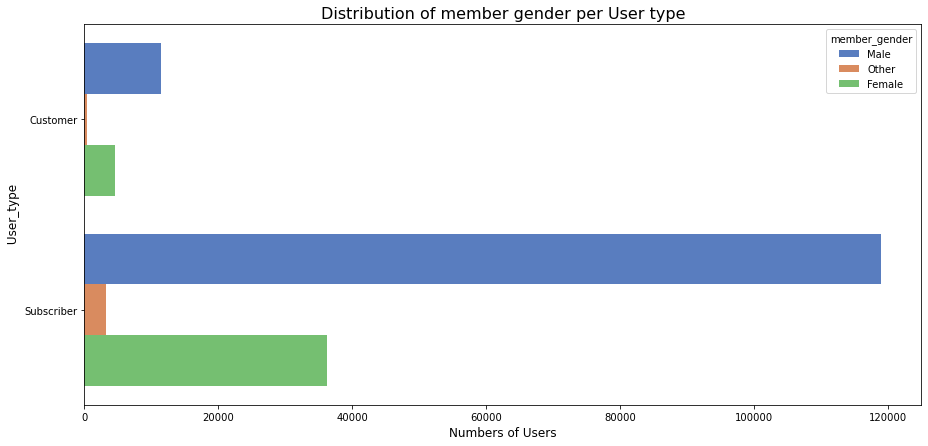

```python
# determine member_gender for every user_type
ax = plt.subplots(figsize = (15,7))
#plot countplot chart from seaborn library with order regard to member_gender.
ax=sb.countplot(data=df_ford, y='user_type', hue='member_gender', palette = 'muted');
ax.set_ylabel(' User_type', fontsize=12)#set y-axis label
ax.set_xlabel('Numbers of Users', fontsize=12)#set x-axis label
ax.set_title('Distribution of member gender per User type',fontsize=16);#set title for chart
```

#### Subscriber users(male>female>other) are greater than customers(male>female>other) in number of trips. Male is greater than female and other gender.

### The relation between star_hour of the day and User type.

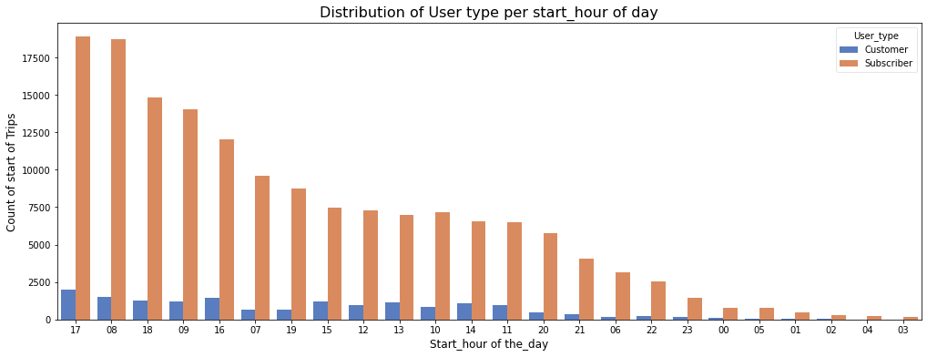

```python
#Explore the relation between user_type and hour of day
plt.figure(figsize=[17,6])
#plot countplot chart from seaborn library with order regard to start_hour.
ax = sb.countplot(data = df_ford, x = 'start_hour', hue = 'user_type', palette = 'muted', order=df_ford.start_hour.value_counts().index)
ax.legend(loc = 1, framealpha = 0.5, title = 'User_type');# set and format legend for the chart.
ax.set_xlabel('Start_hour of the_day', fontsize=12);#set x-axis label.
ax.set_ylabel('Count of start of Trips', fontsize=12);#set y-axis label.
ax.set_title('Distribution of User type per start_hour of day', fontsize=16);# set title for chart.
```

#### The bike riding traffic is very heigh at 17 (5 PM) and 8 (8 AM) o'clock .Subscriber user are heigher in number of trips than Customer a long 24 hours.

### The relation between star hour of the day and member gender.

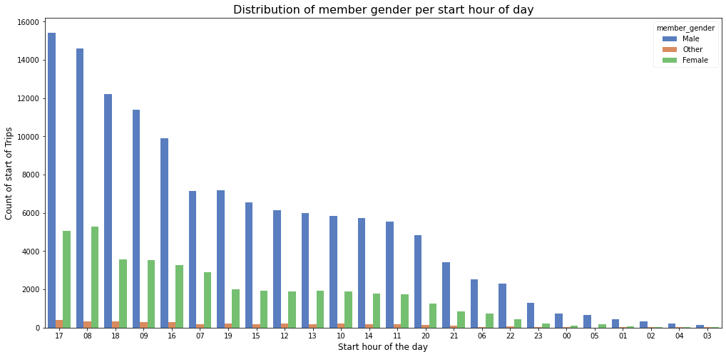

```python
#Explore the relation between member_gender and hour of day
plt.figure(figsize=[17,8])
#plot countplot chart from seaborn library with order regard to member_gender
# use color palette =muted
ax = sb.countplot(data = df_ford, x = 'start_hour', hue = 'member_gender',  palette = 'muted',order=df_ford.start_hour.value_counts().index)
ax.legend(loc = 1, framealpha = 0.3, title = 'member_gender');# set and format legend for the chart.
ax.set_xlabel('Start hour of the day', fontsize=12);#set x-axis label
ax.set_ylabel('Count of start of Trips', fontsize=12);#set y-axis label
ax.set_title('Distribution of member gender per start hour of day', fontsize=16); # set title for chart.
```

#### Male bike riders are a higher number than other and female riders during 24 hours. The traffic jam hour is 7-9 AM in the morning and 16-18(4-6 PM) in the evening.

### The relation between start day of the week and member gender.

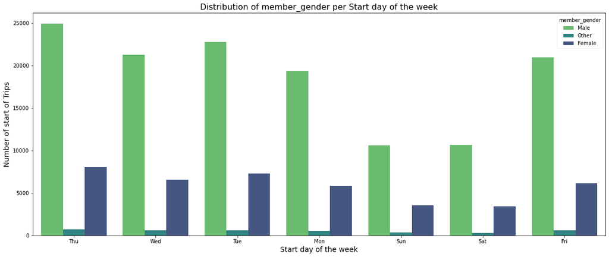

```python
#Explore the relation between member_gender and hour of day
plt.figure(figsize=[20,8])
# Plot countplot chart from seaborn library with order regard to member_gender.
# use color palette =viridis_r
day_gender = sb.countplot(data =df_ford, x = 'start_day_week', hue = 'member_gender', palette = 'viridis_r')
day_gender.legend(loc = 1, framealpha = 0.3, title = 'member_gender');# set and format legend for the chart.
day_gender.set_xlabel('Start day of the week', fontsize=14)#set x-axis label
day_gender.set_ylabel('Number of start of Trips', fontsize=14)#set y-axis label
day_gender.set_title('Distribution of member_gender per Start day of the week', fontsize=16);# set title for chart.
```

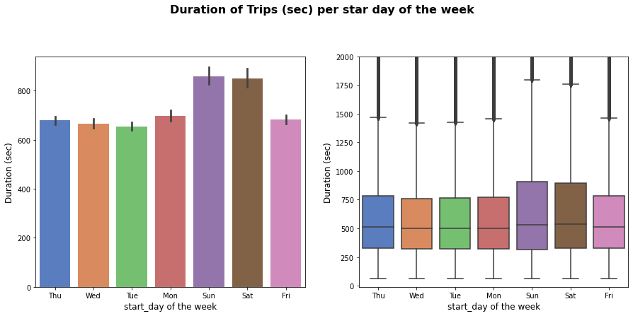

```python
plt.figure(figsize=[15,6])
plt.suptitle('Duration of Trips (sec) per star day of the week', y=1.05, fontsize=16, fontweight='bold')
# left side
plt.subplot(1, 2, 1)
sb.barplot(data=df_ford, x= 'start_day_week', y='duration_sec',palette = 'muted');
plt.ylabel('Duration (sec)',fontsize=12)#set y-axis label
plt.xlabel('start_day of the week',fontsize=12);#set x-axis label

# Rightside
plt.subplot(1, 2, 2)
sb.boxplot(data = df_ford, x = "start_day_week",y='duration_sec',palette = 'muted')
plt.ylabel('Duration (sec)',fontsize=12)#set y-axis label
plt.xlabel('start_day of the week',fontsize=12);#set x-axis label
plt.ylim([-10, 2000]);# limit the duration to 2000 sec to get a clear view.
```

#### Weekends have the largest average of bike trip duration (sec) rather than weekdays.

### The relation between start day of the week and user type.

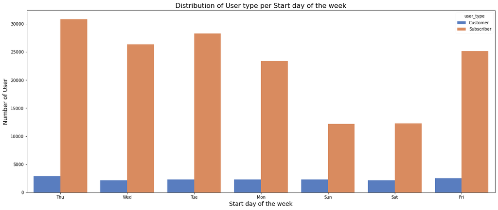

```python
#Explore the relation between member_gender and start_day_week.
plt.figure(figsize=[20,8])
#plot countplot chart from seaborn library with order regard to user_type.
# use color palette =Blues
day_user = sb.countplot(data = df_ford, x = 'start_day_week', hue = 'user_type',  palette = 'muted')
day_user.legend(loc = 1, framealpha = 0.2, title = 'user_type');# set and format legend for the chart.
day_user.set_xlabel('Start day of the week', fontsize=14)#set x-axis label
day_user.set_ylabel('Number of User', fontsize=14)#set y-axis label
day_user.set_title('Distribution of User type per Start day of the week', fontsize=16);# set title for chart.
```

#### Subscribers likely ride a bike during weekdays than weekends, and Customers are relatively constant a long the week.

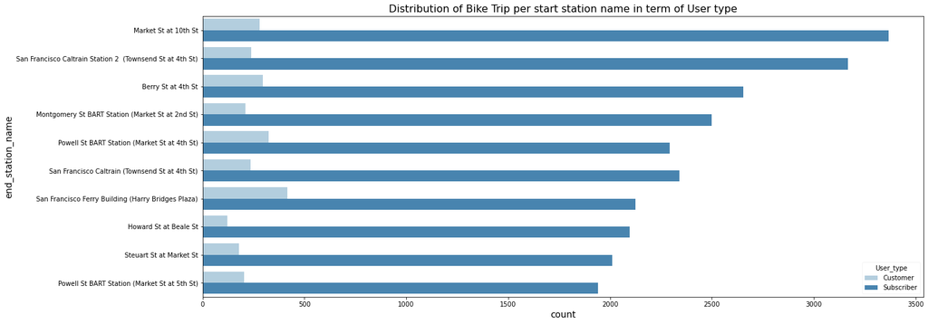

```python
#Explore the relation between user_type and start_station_name
plt.figure(figsize=[20,8])
#plot countplot chart from seaborn library with order regard to start_station_name.
sb.countplot(data = df_ford,  y = 'start_station_name', hue = 'user_type', palette = 'Blues', order=df_ford.start_station_name.value_counts().index[:10]);
plt.legend(loc = 4, framealpha = 0.2, title = 'User_type');# set and format legend for the chart.
plt.title('Distribution of Bike Trip per start station name in term of User type', fontsize=16);#set title for chart
plt.xlabel('count',fontsize=14);#set x-axis label
plt.ylabel('end_station_name',fontsize=14);#set y-axis label
```

The most frequent start station for customer users are :

> 1-San Francisco Ferry Building (Harry Bridges Plaza)

> 2-Powell St BART Station (Market St at 4th St)

> 3-Berry St at 4th St

> 4-Market St at 10th St,

> 5-San Francisco Caltrain Station 2 (Townsend St at 4th St)

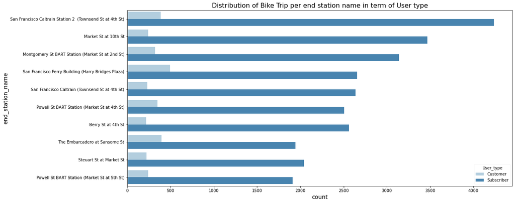

```python
#Explore the relation between user_type and end_station_name
plt.figure(figsize=[17,8])
#plot countplot chart from seaborn library with order regard to start_hour.
sb.countplot(data = df_ford,  y = 'end_station_name', hue = 'user_type', palette = 'Blues', order=df_ford.end_station_name.value_counts().index[:10]);
plt.legend(loc = 4, framealpha = 0.2, title = 'User_type');# set and format legend for the chart.
plt.title('Distribution of Bike Trip per end station name in term of User type', fontsize=16);#set title for chart
plt.xlabel('count',fontsize=14);# set x-axis label
plt.ylabel('end_station_name',fontsize=14);# set y-axis label
```

The most frequent end station ( top 5) for customer users are :

> 1-San Francisco Ferry Building (Harry Bridges Plaza)

> 2-The Embarcadero at Sansome St

> 3- San Francisco Caltrain Station 2 (Townsend St at 4th St)

> 4-Powell St BART Station (Market St at 4th St)

> 5-Montgomery St BART Station (Market St at 2nd St)

> 2-The most frequent end station (top 5)used by Subscribers

> San Francisco Caltrain Station 2 (Townsend St at 4th St),Market St at 10th St,Montgomery St BART Station (Market St at 2nd St),San Francisco Ferry Building (Harry Bridges Plaza) and San Francisco Caltrain (Townsend St at 4th St)

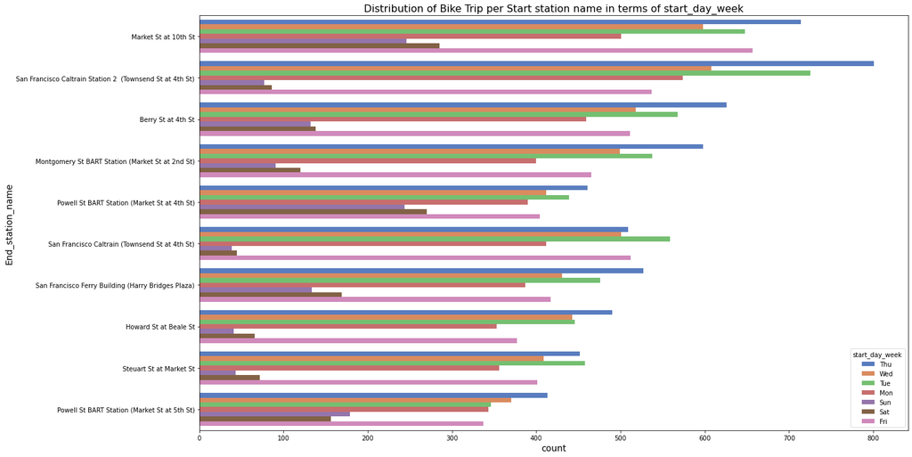

```python
#Explore the distribution of Bike Trip per Start station name in term of start_day_week
plt.figure(figsize=[20,12])
#plot countplot chart from seaborn library with order regard to start_station_name.
sb.countplot(data = df_ford,  y = 'start_station_name', hue = 'start_day_week', palette = 'muted', order=df_ford.start_station_name.value_counts().index[:10]);
plt.legend(loc = 4, framealpha = 0.7, title = 'start_day_week');# set and format legend for the chart.
plt.title('Distribution of Bike Trip per Start station name in terms of start_day_week', fontsize=16);#set title for chart
plt.xlabel('count',fontsize=14);#set x-axis label
plt.ylabel('End_station_name',fontsize=14);#set y-axis label
```

As, it appears from the chart that, the top 5 start stations have the lowest traffic on weekends rather than weekdays are:

> 1-San Francisco Caltrain (Townsend St at 4th St)

> 2-Howard St at Beale St

> 3-Steuart St at Market St

> 4-San Francisco Caltrain Station 2 (Townsend St at 4th St),

> 5-Montgomery St BART Station (Market St at 2nd St),

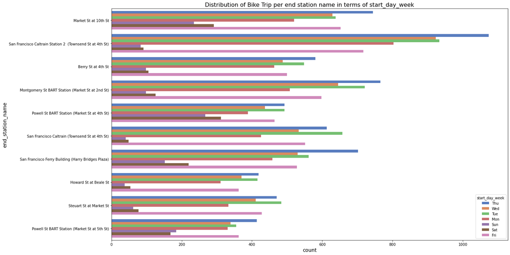

```python
#Explore the Distribution of Bike Trip per end station name in term of start_day_week
plt.figure(figsize=[20,12])
#plot countplot chart from seaborn library with order regard to end_station_name.
sb.countplot(data = df_ford,  y = 'end_station_name', hue = 'start_day_week', palette = 'muted', order=df_ford.start_station_name.value_counts().index[:10]);
plt.legend(loc = 4, framealpha = 0.7, title = 'start_day_week');# set and format legend for the chart.
plt.title('Distribution of Bike Trip per end station name in terms of start_day_week', fontsize=16);#set title for chart
plt.xlabel('count',fontsize=14);#set x-axis label
plt.ylabel('end_station_name',fontsize=14);#set y-axis label
```

As, it appears from the chart that, the top 5 End stations have the lowest traffic on weekends rather than weekdays are:

> 1-San Francisco Caltrain (Townsend St at 4th St)

> 2-Howard St at Beale St

> 3-Steuart St at Market St

> 4-San Francisco Caltrain Station 2 (Townsend St at 4th St),

> 5-Berry St at 4th St,

### Distribution of Bike Sharing per User type

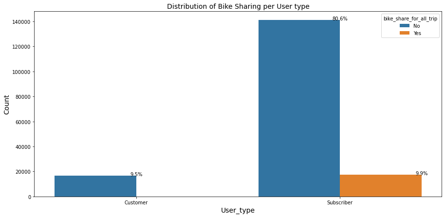

```python
#check if subscribers are the only user type that uses a Bike sharing system or not?
ax = plt.subplots(figsize = (15,7))
ax=sb.countplot(data=df_ford,x='user_type',hue='bike_share_for_all_trip')
ax.set_xlabel('User_type',fontsize=14)#set x-axis label
ax.set_ylabel('Count',fontsize=14)#set y-axis label
ax.set_title('Distribution of Bike Sharing per User type',fontsize=14);
#add percentages on top of bars in seaborn
total = float(len(df_ford))
for p in ax.patches:
    percentage = '{:.1f}%'.format(100 * p.get_height()/total)
    x = p.get_x() + p.get_width()
    y = p.get_height()
    ax.annotate(percentage, (x, y),ha='center')
plt.show()
```

### Subscriber use bike share system for all trip are about 9.9% from total bike rider

### Talk about some of the relationships you observed in this part of the investigation. How did the feature(s) of interest vary with other features in the dataset?

> Relation between Duration (sec) of Bike Trips and Age is an inverse relationship between both variables. As duration(sec) decreased, age increases. The most frequent bike riders have ages between 20 and 45( youth members). Youth members (between 20 and 45) achieved higher trips duration.

> Male bike riders are a higher number than other and female riders. On contract, Other and females ride bikes on longer trips than male riders

> Subscriber users are higher than customers in the number of trips, but customer users have a longer trip duration than Subscriber.Subscriber users(male>female>other) are greater than customers(male>female>other) in number of trips. Subscribers likely ride a bike during weekdays than weekends, and Customers are relatively constant along the week.

> Subscriber use bike share system for all trip are about 9.9% from total bike rider.

### Did you observe any interesting relationships between the other features (not the main feature(s) of interest)?

>

> I have expected that categorical variable's like user type and gender values having higher values to be having higher trip duration but it is the other way round like for gender, the value of male members is very high but the percentage of female members to take longer trips is higher

> In comparing the customer user and the most frequent start station of all trips. There was no direct relation between the most frequent station and the customer.

## Multivariate Exploration

> Create plots of three or more variables to investigate your data even further. Make sure that your investigations are justified, and follow from your work in the previous sections.

#### Distribution of Duration(sec) per Start day of the week for User type

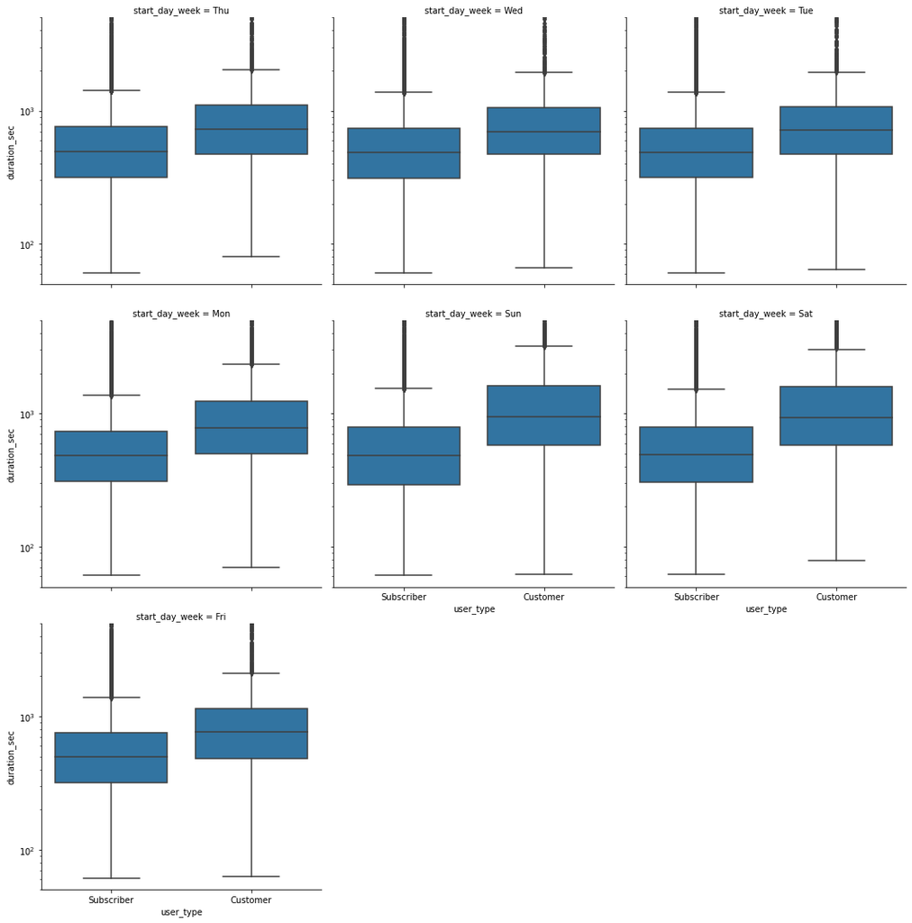

```python
# breakdown the complex pattern ofthe relation between  user _type and  duration_sec for start day of week.
user_start=sb.FacetGrid(data =df_ford, col = 'start_day_week',col_wrap=3, height = 5, margin_titles = True, sharey=True)#sharey=True to have the same scale for all plots
#use seaborn boxplot rather than violin plot.
user_start.map(sb.boxplot,'user_type','duration_sec',order=df_ford.user_type.value_counts().index)
plt.yscale('log')# log transformation to avoid the outlier.
plt.ylim([50, 5000]);#  limit the duration to 5000 sec(83 min) to get a clear view.
```

#### During all days of week the median of trip duration_sec for customer user type is higher than that for subscriber user type.Customer Users have high trip duration than Subscriber.

#### Distribution of Trip Duration(sec) for member gender in terms of Start day of the week

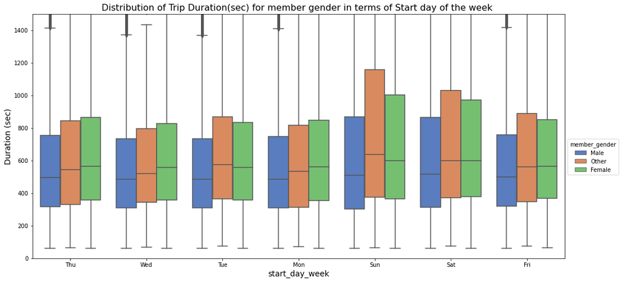

```python
plt.figure(figsize=(17,8))# size of chart
sb.boxplot(x=df_ford.start_day_week, y= df_ford.duration_sec, hue=df_ford.member_gender,palette = 'muted');# select boxplot chart
plt.ylim([0, 1500]);#  limit the duration to 1500 sec(25 min) to get a clear view.
plt.legend(bbox_to_anchor=(1,0.5), framealpha = 0.7, title = 'member_gender');# set and format legend for the chart.
plt.xlabel('start_day_week', fontsize=14)# set label for x-axis
plt.ylabel('Duration (sec)', fontsize=14) # set label for y-axis
plt.title('Distribution of Trip Duration(sec) for member gender in terms of Start day of the week ', fontsize=16);# set title for chart
```

#### the median for Female and other gender have a higher trip duration than male alonge the week.

#### The median for Female is higher than other along the week, except for Sunday and Tuesday other is heigher than female.